# Risk Factor Analysis

## Outcome Variable

**Outcome Variable:** ever_sstunted

## Predictor Variables

**Intervention Variable:** nhh

**Adjustment Set:**

- arm
- W_mage
- meducyrs
- feducyrs
- hhwealth_quart
- W_mhtcm
- W_mwtkg
- W_mbmi
- impfloor
- impsan
- safeh20
- delta_W_mage
- delta_meducyrs
- delta_feducyrs
- delta_hhwealth_quart
- delta_W_mhtcm
- delta_W_mwtkg
- delta_W_mbmi
- delta_impfloor
- delta_impsan
- delta_safeh20

## Stratifying Variables

The analysis was stratified on these variable(s):

- agecat
- studyid
- country

## Data Summary

| agecat | studyid | country | nhh | ever_sstunted | n_cell | n |
| --- | --- | --- | --- | --- | --- | --- |
| 0-24 months | IRC | INDIA | 3 or less | 0 | 47 | 410 |
| 0-24 months | IRC | INDIA | 3 or less | 1 | 11 | 410 |
| 0-24 months | IRC | INDIA | 4-5 | 0 | 114 | 410 |
| 0-24 months | IRC | INDIA | 4-5 | 1 | 44 | 410 |
| 0-24 months | IRC | INDIA | 6-7 | 0 | 80 | 410 |
| 0-24 months | IRC | INDIA | 6-7 | 1 | 27 | 410 |
| 0-24 months | IRC | INDIA | 8+ | 0 | 67 | 410 |
| 0-24 months | IRC | INDIA | 8+ | 1 | 20 | 410 |
| 0-24 months | LCNI-5 | MALAWI | 3 or less | 0 | 183 | 817 |
| 0-24 months | LCNI-5 | MALAWI | 3 or less | 1 | 42 | 817 |
| 0-24 months | LCNI-5 | MALAWI | 4-5 | 0 | 263 | 817 |
| 0-24 months | LCNI-5 | MALAWI | 4-5 | 1 | 77 | 817 |
| 0-24 months | LCNI-5 | MALAWI | 6-7 | 0 | 146 | 817 |
| 0-24 months | LCNI-5 | MALAWI | 6-7 | 1 | 36 | 817 |
| 0-24 months | LCNI-5 | MALAWI | 8+ | 0 | 55 | 817 |
| 0-24 months | LCNI-5 | MALAWI | 8+ | 1 | 15 | 817 |
| 0-24 months | NIH-Birth | BANGLADESH | 3 or less | 0 | 87 | 629 |
| 0-24 months | NIH-Birth | BANGLADESH | 3 or less | 1 | 30 | 629 |
| 0-24 months | NIH-Birth | BANGLADESH | 4-5 | 0 | 172 | 629 |
| 0-24 months | NIH-Birth | BANGLADESH | 4-5 | 1 | 92 | 629 |
| 0-24 months | NIH-Birth | BANGLADESH | 6-7 | 0 | 98 | 629 |
| 0-24 months | NIH-Birth | BANGLADESH | 6-7 | 1 | 44 | 629 |
| 0-24 months | NIH-Birth | BANGLADESH | 8+ | 0 | 76 | 629 |
| 0-24 months | NIH-Birth | BANGLADESH | 8+ | 1 | 30 | 629 |
| 0-24 months | NIH-Crypto | BANGLADESH | 3 or less | 0 | 102 | 758 |
| 0-24 months | NIH-Crypto | BANGLADESH | 3 or less | 1 | 12 | 758 |
| 0-24 months | NIH-Crypto | BANGLADESH | 4-5 | 0 | 295 | 758 |
| 0-24 months | NIH-Crypto | BANGLADESH | 4-5 | 1 | 47 | 758 |
| 0-24 months | NIH-Crypto | BANGLADESH | 6-7 | 0 | 153 | 758 |
| 0-24 months | NIH-Crypto | BANGLADESH | 6-7 | 1 | 25 | 758 |
| 0-24 months | NIH-Crypto | BANGLADESH | 8+ | 0 | 109 | 758 |
| 0-24 months | NIH-Crypto | BANGLADESH | 8+ | 1 | 15 | 758 |
| 0-24 months | PROVIDE | BANGLADESH | 3 or less | 0 | 117 | 700 |
| 0-24 months | PROVIDE | BANGLADESH | 3 or less | 1 | 23 | 700 |
| 0-24 months | PROVIDE | BANGLADESH | 4-5 | 0 | 280 | 700 |
| 0-24 months | PROVIDE | BANGLADESH | 4-5 | 1 | 42 | 700 |
| 0-24 months | PROVIDE | BANGLADESH | 6-7 | 0 | 135 | 700 |
| 0-24 months | PROVIDE | BANGLADESH | 6-7 | 1 | 16 | 700 |
| 0-24 months | PROVIDE | BANGLADESH | 8+ | 0 | 73 | 700 |
| 0-24 months | PROVIDE | BANGLADESH | 8+ | 1 | 14 | 700 |
| 0-24 months | SAS-FoodSuppl | INDIA | 3 or less | 0 | 28 | 418 |
| 0-24 months | SAS-FoodSuppl | INDIA | 3 or less | 1 | 10 | 418 |
| 0-24 months | SAS-FoodSuppl | INDIA | 4-5 | 0 | 97 | 418 |
| 0-24 months | SAS-FoodSuppl | INDIA | 4-5 | 1 | 86 | 418 |
| 0-24 months | SAS-FoodSuppl | INDIA | 6-7 | 0 | 58 | 418 |
| 0-24 months | SAS-FoodSuppl | INDIA | 6-7 | 1 | 69 | 418 |
| 0-24 months | SAS-FoodSuppl | INDIA | 8+ | 0 | 34 | 418 |
| 0-24 months | SAS-FoodSuppl | INDIA | 8+ | 1 | 36 | 418 |

The following strata were considered:

- agecat: 0-24 months, studyid: IRC, country: INDIA
- agecat: 0-24 months, studyid: LCNI-5, country: MALAWI
- agecat: 0-24 months, studyid: NIH-Birth, country: BANGLADESH
- agecat: 0-24 months, studyid: NIH-Crypto, country: BANGLADESH
- agecat: 0-24 months, studyid: PROVIDE, country: BANGLADESH
- agecat: 0-24 months, studyid: SAS-FoodSuppl, country: INDIA

## Methods Detail

We're interested in the causal parameters $E[Y_a]$ for all values of $a \in \mathcal{A}$. These parameters represent the mean outcome if, possibly contrary to fact, we intervened to set all units to have $A=a$. Under the randomization and positivity assumptions, these are identified by the statistical parameters $\psi_a=E_W[E_{Y|A,W}(Y|A=a,W)]$. In addition, we're interested in the mean of $Y$, $E[Y]$ under no intervention (the observed mean). We will estimate these parameters by using SuperLearner to fit the relevant likelihood factors -- $E_{Y|A,W}(Y|A=a,W)$ and $p(A=a|W)$, and then updating our likelihood fit using a joint TMLE.

For unadjusted analyses ($W=\{\}$), initial likelihoods were estimated using Lrnr_glm to estimate the simple $E(Y|A)$ and Lrnr_mean to estimate $p(A)$. For adjusted analyses, a small library containing Lrnr_glmnet, Lrnr_xgboost, and Lrnr_mean was used.

Having estimated these parameters, we will then use the delta method to estimate relative risks and attributable risks relative to a prespecified baseline level of $A$.

# Results Detail

## Results Plots

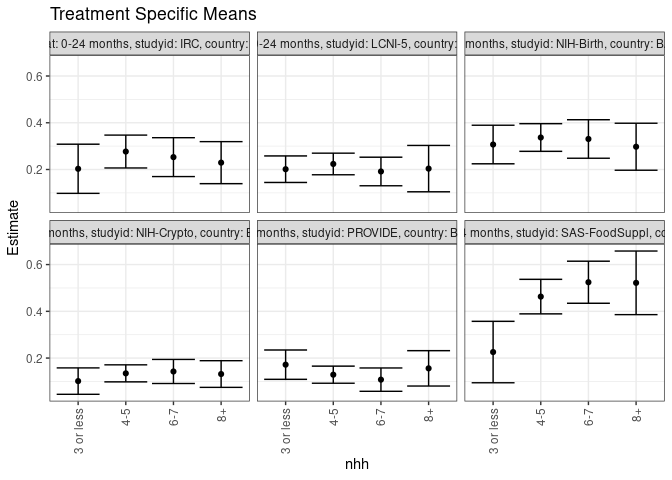

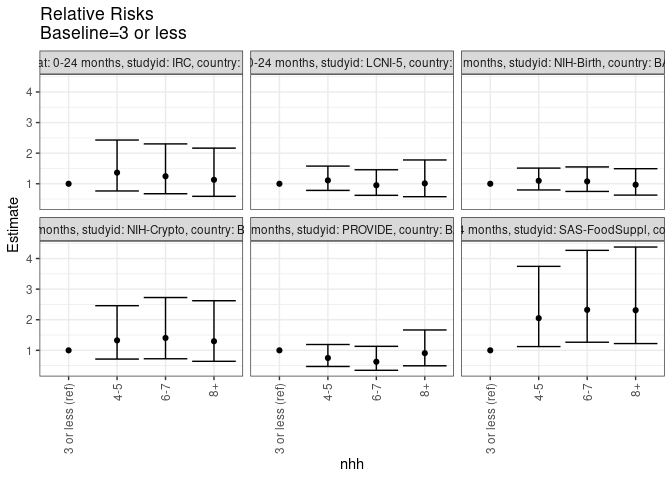

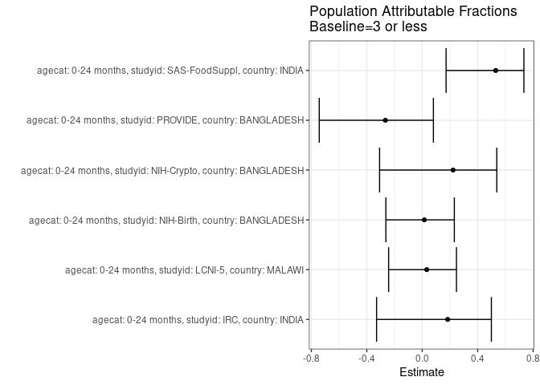

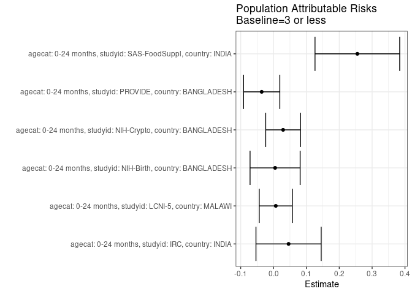

## Results Table

### Parameter: TSM

| agecat | studyid | country | intervention_level | baseline_level | estimate | ci_lower | ci_upper |
| --- | --- | --- | --- | --- | --- | --- | --- |
| 0-24 months | IRC | INDIA | 3 or less | NA | 0.2030063 | 0.0977676 | 0.3082450 |
| 0-24 months | IRC | INDIA | 4-5 | NA | 0.2768093 | 0.2064606 | 0.3471580 |
| 0-24 months | IRC | INDIA | 6-7 | NA | 0.2528983 | 0.1698285 | 0.3359682 |
| 0-24 months | IRC | INDIA | 8+ | NA | 0.2293172 | 0.1394007 | 0.3192336 |
| 0-24 months | LCNI-5 | MALAWI | 3 or less | NA | 0.2012359 | 0.1444682 | 0.2580037 |
| 0-24 months | LCNI-5 | MALAWI | 4-5 | NA | 0.2236719 | 0.1774623 | 0.2698815 |
| 0-24 months | LCNI-5 | MALAWI | 6-7 | NA | 0.1915333 | 0.1304503 | 0.2526163 |
| 0-24 months | LCNI-5 | MALAWI | 8+ | NA | 0.2037601 | 0.1045961 | 0.3029240 |
| 0-24 months | NIH-Birth | BANGLADESH | 3 or less | NA | 0.3068479 | 0.2243182 | 0.3893775 |
| 0-24 months | NIH-Birth | BANGLADESH | 4-5 | NA | 0.3368833 | 0.2776948 | 0.3960718 |
| 0-24 months | NIH-Birth | BANGLADESH | 6-7 | NA | 0.3305670 | 0.2482032 | 0.4129309 |
| 0-24 months | NIH-Birth | BANGLADESH | 8+ | NA | 0.2974118 | 0.1968014 | 0.3980223 |
| 0-24 months | NIH-Crypto | BANGLADESH | 3 or less | NA | 0.1015079 | 0.0449925 | 0.1580233 |
| 0-24 months | NIH-Crypto | BANGLADESH | 4-5 | NA | 0.1346138 | 0.0982017 | 0.1710260 |
| 0-24 months | NIH-Crypto | BANGLADESH | 6-7 | NA | 0.1426277 | 0.0911600 | 0.1940954 |
| 0-24 months | NIH-Crypto | BANGLADESH | 8+ | NA | 0.1317015 | 0.0746345 | 0.1887686 |
| 0-24 months | PROVIDE | BANGLADESH | 3 or less | NA | 0.1717882 | 0.1090200 | 0.2345564 |
| 0-24 months | PROVIDE | BANGLADESH | 4-5 | NA | 0.1289252 | 0.0922987 | 0.1655516 |
| 0-24 months | PROVIDE | BANGLADESH | 6-7 | NA | 0.1077374 | 0.0578588 | 0.1576159 |
| 0-24 months | PROVIDE | BANGLADESH | 8+ | NA | 0.1560434 | 0.0803868 | 0.2317000 |
| 0-24 months | SAS-FoodSuppl | INDIA | 3 or less | NA | 0.2257683 | 0.0943781 | 0.3571586 |
| 0-24 months | SAS-FoodSuppl | INDIA | 4-5 | NA | 0.4630086 | 0.3891254 | 0.5368918 |
| 0-24 months | SAS-FoodSuppl | INDIA | 6-7 | NA | 0.5245159 | 0.4345321 | 0.6144996 |
| 0-24 months | SAS-FoodSuppl | INDIA | 8+ | NA | 0.5218630 | 0.3857966 | 0.6579295 |

### Parameter: E(Y)

| agecat | studyid | country | intervention_level | baseline_level | estimate | ci_lower | ci_upper |
| --- | --- | --- | --- | --- | --- | --- | --- |
| 0-24 months | IRC | INDIA | NA | NA | 0.2487805 | 0.2068840 | 0.2906770 |
| 0-24 months | LCNI-5 | MALAWI | NA | NA | 0.2080783 | 0.1802263 | 0.2359304 |
| 0-24 months | NIH-Birth | BANGLADESH | NA | NA | 0.3116057 | 0.2753823 | 0.3478292 |
| 0-24 months | NIH-Crypto | BANGLADESH | NA | NA | 0.1306069 | 0.1066024 | 0.1546113 |
| 0-24 months | PROVIDE | BANGLADESH | NA | NA | 0.1357143 | 0.1103250 | 0.1611036 |
| 0-24 months | SAS-FoodSuppl | INDIA | NA | NA | 0.4808612 | 0.4329065 | 0.5288160 |

### Parameter: RR

| agecat | studyid | country | intervention_level | baseline_level | estimate | ci_lower | ci_upper |
| --- | --- | --- | --- | --- | --- | --- | --- |
| 0-24 months | IRC | INDIA | 3 or less | 3 or less | 1.0000000 | 1.0000000 | 1.000000 |
| 0-24 months | IRC | INDIA | 4-5 | 3 or less | 1.3635506 | 0.7652764 | 2.429541 |
| 0-24 months | IRC | INDIA | 6-7 | 3 or less | 1.2457663 | 0.6741019 | 2.302224 |
| 0-24 months | IRC | INDIA | 8+ | 3 or less | 1.1296064 | 0.5895596 | 2.164345 |
| 0-24 months | LCNI-5 | MALAWI | 3 or less | 3 or less | 1.0000000 | 1.0000000 | 1.000000 |
| 0-24 months | LCNI-5 | MALAWI | 4-5 | 3 or less | 1.1114910 | 0.7833854 | 1.577017 |
| 0-24 months | LCNI-5 | MALAWI | 6-7 | 3 or less | 0.9517846 | 0.6216722 | 1.457189 |
| 0-24 months | LCNI-5 | MALAWI | 8+ | 3 or less | 1.0125431 | 0.5768065 | 1.777448 |
| 0-24 months | NIH-Birth | BANGLADESH | 3 or less | 3 or less | 1.0000000 | 1.0000000 | 1.000000 |
| 0-24 months | NIH-Birth | BANGLADESH | 4-5 | 3 or less | 1.0978838 | 0.7969662 | 1.512422 |
| 0-24 months | NIH-Birth | BANGLADESH | 6-7 | 3 or less | 1.0772994 | 0.7488292 | 1.549852 |
| 0-24 months | NIH-Birth | BANGLADESH | 8+ | 3 or less | 0.9692486 | 0.6295682 | 1.492202 |
| 0-24 months | NIH-Crypto | BANGLADESH | 3 or less | 3 or less | 1.0000000 | 1.0000000 | 1.000000 |
| 0-24 months | NIH-Crypto | BANGLADESH | 4-5 | 3 or less | 1.3261415 | 0.7152320 | 2.458855 |
| 0-24 months | NIH-Crypto | BANGLADESH | 6-7 | 3 or less | 1.4050900 | 0.7242583 | 2.725931 |
| 0-24 months | NIH-Crypto | BANGLADESH | 8+ | 3 or less | 1.2974510 | 0.6422002 | 2.621269 |
| 0-24 months | PROVIDE | BANGLADESH | 3 or less | 3 or less | 1.0000000 | 1.0000000 | 1.000000 |
| 0-24 months | PROVIDE | BANGLADESH | 4-5 | 3 or less | 0.7504890 | 0.4728183 | 1.191226 |
| 0-24 months | PROVIDE | BANGLADESH | 6-7 | 3 or less | 0.6271522 | 0.3477552 | 1.131025 |
| 0-24 months | PROVIDE | BANGLADESH | 8+ | 3 or less | 0.9083474 | 0.4952486 | 1.666022 |
| 0-24 months | SAS-FoodSuppl | INDIA | 3 or less | 3 or less | 1.0000000 | 1.0000000 | 1.000000 |
| 0-24 months | SAS-FoodSuppl | INDIA | 4-5 | 3 or less | 2.0508127 | 1.1231098 | 3.744810 |
| 0-24 months | SAS-FoodSuppl | INDIA | 6-7 | 3 or less | 2.3232482 | 1.2647992 | 4.267462 |
| 0-24 months | SAS-FoodSuppl | INDIA | 8+ | 3 or less | 2.3114977 | 1.2211464 | 4.375415 |

### Parameter: PAR

| agecat | studyid | country | intervention_level | baseline_level | estimate | ci_lower | ci_upper |
| --- | --- | --- | --- | --- | --- | --- | --- |
| 0-24 months | IRC | INDIA | 3 or less | NA | 0.0457742 | -0.0534726 | 0.1450211 |
| 0-24 months | LCNI-5 | MALAWI | 3 or less | NA | 0.0068424 | -0.0435655 | 0.0572503 |
| 0-24 months | NIH-Birth | BANGLADESH | 3 or less | NA | 0.0047579 | -0.0714587 | 0.0809744 |
| 0-24 months | NIH-Crypto | BANGLADESH | 3 or less | NA | 0.0290990 | -0.0238265 | 0.0820244 |
| 0-24 months | PROVIDE | BANGLADESH | 3 or less | NA | -0.0360739 | -0.0912326 | 0.0190847 |
| 0-24 months | SAS-FoodSuppl | INDIA | 3 or less | NA | 0.2550929 | 0.1262022 | 0.3839836 |

### Parameter: PAF

| agecat | studyid | country | intervention_level | baseline_level | estimate | ci_lower | ci_upper |
| --- | --- | --- | --- | --- | --- | --- | --- |
| 0-24 months | IRC | INDIA | 3 or less | NA | 0.1839945 | -0.3292367 | 0.4990621 |
| 0-24 months | LCNI-5 | MALAWI | 3 or less | NA | 0.0328838 | -0.2422739 | 0.2470954 |
| 0-24 months | NIH-Birth | BANGLADESH | 3 or less | NA | 0.0152689 | -0.2622605 | 0.2317787 |
| 0-24 months | NIH-Crypto | BANGLADESH | 3 or less | NA | 0.2227982 | -0.3076043 | 0.5380539 |
| 0-24 months | PROVIDE | BANGLADESH | 3 or less | NA | -0.2658078 | -0.7430766 | 0.0807809 |
| 0-24 months | SAS-FoodSuppl | INDIA | 3 or less | NA | 0.5304917 | 0.1722932 | 0.7336762 |